# dplyr

MSc Liliana Millán, liliana.millan@gmail.com

Febrero, 2017

### Agenda

- Paquetes del mundo de Hadley Wickham
- Operaciones en vectores
- Verbos de dplyr
- select
- filter
- group by
- summarise
- mutate
- arrange
- *tidyr*
- Tarea
- Tutoriales
- Referencias

### Paquetes para manipulación y limpieza de datos

- Manipuación de fechas [lubridate](https://cran.r-project.org/web/packages/lubridate/vignettes/lubridate.html)
- Limpieza de datos [tidyr](https://blog.rstudio.org/2014/07/22/introducing-tidyr/)
- Manipulacion de datos [dplyr](https://cran.rstudio.com/web/packages/dplyr/vignettes/introduction.html)
- Pipes de instrucciones magrittr

```r
library(dplyr)
library(tidyr)
library(lubridate)
library(readr)
library(knitr)
library(stringr)
```

### Operaciones vectoriales

- sumas, multiplicaciones, divisiones

```r
a <- c(13.5,12.1,7.5,9.3,100.2)
b <- c(1.5,2,3.8,9.2,11)

#suma
a + b
```

```
## [1]  15.0  14.1  11.3  18.5 111.2
```

```r
#multiplicacion
a * b
```

```
## [1]   20.25   24.20   28.50   85.56 1102.20
```

```r
#division
a / b
```

```
## [1] 9.000000 6.050000 1.973684 1.010870 9.109091
```

```r
#generamos una secuencia del 1:10
x <- 1:10
#creamos una matriz ... los valores los pone por columna
z <- matrix(x, nrow=5)
z
```

```
##      [,1] [,2]
## [1,]    1    6
## [2,]    2    7
## [3,]    3    8
## [4,]    4    9
## [5,]    5   10
```

```r
#creamos una matriz ... los valores lso pone por renglon
y <- matrix(x, nrow=2, byrow=T)
y
```

```
##      [,1] [,2] [,3] [,4] [,5]
## [1,]    1    2    3    4    5
## [2,]    6    7    8    9   10
```

```r
#multiplicacion de matrices
y %*% z
```

```
##      [,1] [,2]
## [1,]   55  130
## [2,]  130  330
```

- ifelse vs if, else

```r
df <- data.frame(var1=c("hola","adios","hola","adios","adios"),
                 var2=c(15,9,11,23,2))

if(df$var1 == 'hola'){
  print('hi')
} else {
  print('bye')
}
```

```
## [1] "hi"
```

```r
df$var3 <- ifelse(df$var1=="hola",1,0)
df
```

```
##    var1 var2 var3
## 1  hola   15    1
## 2 adios    9    0
## 3  hola   11    1
## 4 adios   23    0
## 5 adios    2    0
```

- And’s y Or’s `&`, `|`

Tabla de verdad AND los dos 1

| x | y | AND |
| --- | --- | --- |
| 0 | 0 | 0 |
| 0 | 1 | 0 |
| 1 | 0 | 0 |
| 1 | 1 | 1 |

```r
#and logico vectorial
x <- c(0,0,1,1)
y <- c(0,1,0,1)

x & y
```

```
## [1] FALSE FALSE FALSE  TRUE
```

```r
#and logico elemento por elemento
x && y
```

```
## [1] FALSE
```

Tabla de verdad de OR (al menos un 1)

| x | y | AND |
| --- | --- | --- |
| 0 | 0 | 0 |
| 0 | 1 | 1 |
| 1 | 0 | 1 |
| 1 | 1 | 1 |

```r
#or logico vectorial
x | y
```

```
## [1] FALSE  TRUE  TRUE  TRUE
```

```r
#or logico elemento por elemento, solo revisa el primer elemento!
x || y
```

```
## [1] FALSE
```

Normalmente querrás ocupar `&` y `|` para hacer las operaciones vectoriales

- repeticiones

```r
f <- c(rep(5, 4), 2, rep(2, 5))
f
```

```
##  [1] 5 5 5 5 2 2 2 2 2 2
```

- generar aleatorios

```r
set.seed(170271)

#de distribucion uniforme
aleatorios_uniformes <- runif(15, min=0, max=10)
aleatorios_uniformes
```

```
##  [1] 2.1012698 3.8262685 8.8536613 2.4930546 3.3973128 6.5137422 0.7712503
##  [8] 6.3436307 3.0929135 1.2180072 3.6850844 4.0194170 7.0636788 7.8502707
## [15] 1.6272545
```

```r
#de distribucion normal
aleatorios_normales <- rnorm(15, mean=0, sd=1)
aleatorios_normales
```

```
##  [1] -0.21816220  0.62057895  0.78341368 -0.22035472  0.15593377
##  [6] -0.03020602  0.57072311  1.10842715 -0.31814144 -2.21238561
## [11]  1.52962954 -0.42484378 -0.83582310 -0.60402543  0.85839320
```

```r
#de distribucion binomial
#tamaño de conjunto, numero de elementos, probabilidad de exito
aleatorios_binomial <- rbinom(15, 1, 0.6)
aleatorios_binomial
```

```
##  [1] 1 1 1 1 1 1 1 1 0 0 0 1 1 0 0
```

```r
#aleatorios enteros
sample(1:10, size=5, replace=T)
```

```
## [1]  3  6  6  2 10
```

```r
#aleatorios enteros
sample(1:10, size=5, replace=F)
```

```
## [1]  3  5 10  4  2
```

- sapply, lapply, mapply, apply

Estas funciones nos permiten aplicar operaciones propias u otras funciones a los elementos de un data frame. **sapply** regresará la respuesta de haber aplicado una o más funciones como una lista —al objeto más eficiente que el identifique—, **lapply** regresará siempre una lista, **mapply** regresará una matriz, y **apply** hay que especificarle si le queremos enviar las columnas del data frame o los renglones del data frame puede regresar un vector, arreglo o lista.

Al utilizar estos métodos se evita el uso de for… en R son muy poco óptimos —recordemos que no es un lenguaje de uso general—

```r
breast_cancer <- read_csv("~/Documents/itam/mineria_datos_licenciatura/data/breast_cancer.csv")
names(breast_cancer)
```

```
##  [1] "id"                      "diagnosis"
##  [3] "radius_mean"             "texture_mean"
##  [5] "perimeter_mean"          "area_mean"
##  [7] "smoothness_mean"         "compactness_mean"
##  [9] "concavity_mean"          "concave points_mean"
## [11] "symmetry_mean"           "fractal_dimension_mean"
## [13] "radius_se"               "texture_se"
## [15] "perimeter_se"            "area_se"
## [17] "smoothness_se"           "compactness_se"
## [19] "concavity_se"            "concave points_se"
## [21] "symmetry_se"             "fractal_dimension_se"
## [23] "radius_worst"            "texture_worst"
## [25] "perimeter_worst"         "area_worst"
## [27] "smoothness_worst"        "compactness_worst"
## [29] "concavity_worst"         "concave points_worst"
## [31] "symmetry_worst"          "fractal_dimension_worst"
```

```r
#cambiemos los nombres que no tienen guion bajo! verifica la documentacion de str_replace y str_replace_all
names(breast_cancer) <- str_replace_all(names(breast_cancer), " ", "_")
names(breast_cancer)
```

```
##  [1] "id"                      "diagnosis"
##  [3] "radius_mean"             "texture_mean"
##  [5] "perimeter_mean"          "area_mean"
##  [7] "smoothness_mean"         "compactness_mean"
##  [9] "concavity_mean"          "concave_points_mean"
## [11] "symmetry_mean"           "fractal_dimension_mean"
## [13] "radius_se"               "texture_se"
## [15] "perimeter_se"            "area_se"
## [17] "smoothness_se"           "compactness_se"
## [19] "concavity_se"            "concave_points_se"
## [21] "symmetry_se"             "fractal_dimension_se"
## [23] "radius_worst"            "texture_worst"
## [25] "perimeter_worst"         "area_worst"
## [27] "smoothness_worst"        "compactness_worst"
## [29] "concavity_worst"         "concave_points_worst"
## [31] "symmetry_worst"          "fractal_dimension_worst"
```

```r
#uso de grep
names(breast_cancer)[grep("radius_se$", names(breast_cancer))] <- "radius_se_test"
names(breast_cancer)
```

```
##  [1] "id"                      "diagnosis"
##  [3] "radius_mean"             "texture_mean"
##  [5] "perimeter_mean"          "area_mean"
##  [7] "smoothness_mean"         "compactness_mean"
##  [9] "concavity_mean"          "concave_points_mean"
## [11] "symmetry_mean"           "fractal_dimension_mean"
## [13] "radius_se_test"          "texture_se"
## [15] "perimeter_se"            "area_se"
## [17] "smoothness_se"           "compactness_se"
## [19] "concavity_se"            "concave_points_se"
## [21] "symmetry_se"             "fractal_dimension_se"
## [23] "radius_worst"            "texture_worst"
## [25] "perimeter_worst"         "area_worst"
## [27] "smoothness_worst"        "compactness_worst"
## [29] "concavity_worst"         "concave_points_worst"
## [31] "symmetry_worst"          "fractal_dimension_worst"
```

```r
names(breast_cancer)[grep("test", names(breast_cancer))] <- "radius_se"
names(breast_cancer)
```

```
##  [1] "id"                      "diagnosis"
##  [3] "radius_mean"             "texture_mean"
##  [5] "perimeter_mean"          "area_mean"
##  [7] "smoothness_mean"         "compactness_mean"
##  [9] "concavity_mean"          "concave_points_mean"
## [11] "symmetry_mean"           "fractal_dimension_mean"
## [13] "radius_se"               "texture_se"
## [15] "perimeter_se"            "area_se"
## [17] "smoothness_se"           "compactness_se"
## [19] "concavity_se"            "concave_points_se"
## [21] "symmetry_se"             "fractal_dimension_se"
## [23] "radius_worst"            "texture_worst"
## [25] "perimeter_worst"         "area_worst"
## [27] "smoothness_worst"        "compactness_worst"
## [29] "concavity_worst"         "concave_points_worst"
## [31] "symmetry_worst"          "fractal_dimension_worst"
```

```r
nulos <- sapply(breast_cancer, function(x) sum(is.na(x)))
nulos
```

```
##                      id               diagnosis             radius_mean
##                       0                       0                       0
##            texture_mean          perimeter_mean               area_mean
##                       0                       0                       0
##         smoothness_mean        compactness_mean          concavity_mean
##                       0                       0                       0
##     concave_points_mean           symmetry_mean  fractal_dimension_mean
##                       0                       0                       0
##               radius_se              texture_se            perimeter_se
##                       0                       0                       0
##                 area_se           smoothness_se          compactness_se
##                       0                       0                       0
##            concavity_se       concave_points_se             symmetry_se
##                       0                       0                       0
##    fractal_dimension_se            radius_worst           texture_worst
##                       0                       0                       0
##         perimeter_worst              area_worst        smoothness_worst
##                       0                       0                       0
##       compactness_worst         concavity_worst    concave_points_worst
##                       0                       0                       0
##          symmetry_worst fractal_dimension_worst
##                       0                       0
```

```r
#funcion para calcular la moda
mode_calc <- function(x){
  table(x) %>%
    which.max() %>%
    names()
}

modes <- sapply(breast_cancer, function(x) mode_calc(x))
modes
```

```
##                      id               diagnosis             radius_mean
##                  "8670"                     "B"                 "12.34"
##            texture_mean          perimeter_mean               area_mean
##                 "14.93"                 "82.61"                 "512.2"
##         smoothness_mean        compactness_mean          concavity_mean
##                "0.1007"                "0.1147"                     "0"
##     concave_points_mean           symmetry_mean  fractal_dimension_mean
##                     "0"                "0.1601"               "0.05667"
##               radius_se              texture_se            perimeter_se
##                "0.2204"                "0.8561"                 "1.778"
##                 area_se           smoothness_se          compactness_se
##                 "16.64"               "0.00508"               "0.01104"
##            concavity_se       concave_points_se             symmetry_se
##                     "0"                     "0"               "0.01344"
##    fractal_dimension_se            radius_worst           texture_worst
##              "0.001784"                 "12.36"                  "17.7"
##         perimeter_worst              area_worst        smoothness_worst
##                 "101.7"                 "284.4"                "0.1216"
##       compactness_worst         concavity_worst    concave_points_worst
##                "0.1486"                     "0"                     "0"
##          symmetry_worst fractal_dimension_worst
##                "0.2226"               "0.07427"
```

### dplyr

dplyr permite manipular los datos como los utilizarias ocupando sql. Los verbos de dplyr son: select, filter, group_by, summarise, mutate, arrange, join.

Supón que queremos obtener del set de datos de cáncer de mama cuántas observaciones hay por tipo de tumor. En sql sería:

`select diagnosis, count(*) from breast_cancer group by diagnosis`

En dplyr *select* se ocupa como en sql para seleccionar las columnas que queremos que formen parte de la respuesta, *group_by* hace lo mismo que en sql agrupa un set de datos por alguna columna(s), el from de sql corresponde a indicar el data frame en donde realizaremos la consulta, count(*) forma parte de una agregación, esto es… por cada grupo encontrado regresará **1 y solo 1 número asociado…** compacta un set de datos a un solo renglón, para hacer esta agregación en dplyr ocupamos *summarise* en donde indicamos qué operación queremos hacer para la agregación, count(*) es un `n()` en dplyr, también se puede sacar `mean()`, `sd()`, `median()`, una función definida por nosotros, etc. Para unir todas las funciones ocupamos *magrittr* `%>%` -si vienes del mundo de unix este operador es el pipe! `|`-.

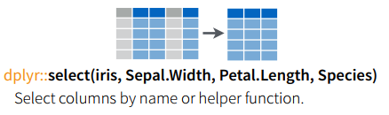

```r
grupos_tumores <- breast_cancer %>% group_by(diagnosis) %>%
  summarise(count=n())

grupos_tumores
```

```
## # A tibble: 2 x 2
##   diagnosis count
##       <chr> <int>
## 1         B   357
## 2         M   212
```

La salida de `group by` regresa las cosas ordenadas alfabéticamente -por la columna con la que hizo agruapción-, si quisieramos arreglar la salida por tamaño del grupo de mayor a menor, en sql sería:

`select diagnosis, count(*) from breast_cancer group by diagnosis order by count(*) desc`

En dplyr ocupamos *arrange*, por default se ordenand de manera ascendente por lo que debemos indicar que lo queremos de manera descendiente y por cuál columna vamos a ordenar

```r
grupos_tumores <- breast_cancer %>% group_by(diagnosis) %>%
  summarise(count=n()) %>% arrange(desc(count))

grupos_tumores
```

```
## # A tibble: 2 x 2
##   diagnosis count
##       <chr> <int>
## 1         B   357
## 2         M   212
```

La función *mutate* permite agregar una columna que no existía en el data frame original ocupando columnas que se hayan generado a través de summarise

```r
grupos_tumores <- breast_cancer %>% group_by(diagnosis) %>%
  summarise(count=n()) %>%
  mutate(prop=count/sum(count)) %>%
  arrange(desc(prop))

grupos_tumores
```

```
## # A tibble: 2 x 3
##   diagnosis count      prop
##       <chr> <int>     <dbl>
## 1         B   357 0.6274165
## 2         M   212 0.3725835
```

Esto también se pudo haber hecho con el método *prop.table* … es parte de lo bonito de R, una misma cosa se puede hacer de muchas maneras diferentes :)

```r
#revisa la documentacion de table y prop.table! te servirán en el curso
alternativa <- prop.table(table(breast_cancer$diagnosis))
alternativa
```

```
##
##         B         M
## 0.6274165 0.3725835
```

La función *filter* permite filtrar un data frame por alguna conidicion(es) que los renglones deban cumplir, por ejemplo: si quisieramos obtener las observaciones que corresponden a tumores benignos, en sql sería:

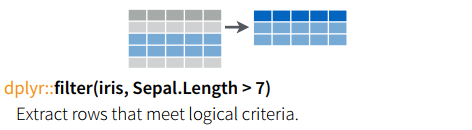

`select * from breast_cancer where diaganosis = 'B'`

En dplyr sería:

```r
breast_cancer %>% filter(diagnosis == "B")
```

```
## # A tibble: 357 x 32
##          id diagnosis radius_mean texture_mean perimeter_mean area_mean
##       <int>     <chr>       <dbl>        <dbl>          <dbl>     <dbl>
##  1  8510426         B      13.540        14.36          87.46     566.3
##  2  8510653         B      13.080        15.71          85.63     520.0
##  3  8510824         B       9.504        12.44          60.34     273.9
##  4   854941         B      13.030        18.42          82.61     523.8
##  5 85713702         B       8.196        16.84          51.71     201.9
##  6   857155         B      12.050        14.63          78.04     449.3
##  7   857156         B      13.490        22.30          86.91     561.0
##  8   857343         B      11.760        21.60          74.72     427.9
##  9   857373         B      13.640        16.34          87.21     571.8
## 10   857374         B      11.940        18.24          75.71     437.6
## # ... with 347 more rows, and 26 more variables: smoothness_mean <dbl>,
## #   compactness_mean <dbl>, concavity_mean <dbl>,
## #   concave_points_mean <dbl>, symmetry_mean <dbl>,
## #   fractal_dimension_mean <dbl>, radius_se <dbl>, texture_se <dbl>,
## #   perimeter_se <dbl>, area_se <dbl>, smoothness_se <dbl>,
## #   compactness_se <dbl>, concavity_se <dbl>, concave_points_se <dbl>,
## #   symmetry_se <dbl>, fractal_dimension_se <dbl>, radius_worst <dbl>,
## #   texture_worst <dbl>, perimeter_worst <dbl>, area_worst <dbl>,
## #   smoothness_worst <dbl>, compactness_worst <dbl>,
## #   concavity_worst <dbl>, concave_points_worst <dbl>,
## #   symmetry_worst <dbl>, fractal_dimension_worst <dbl>
```

Nota el uso de doble igual `==` porque es una condición lógica a probar

Se puede hacer *filter* por más de una condición a la vez, por ejemplo: si quisieramos obtener los tumores que son beningnos y un radio promedio mayor o igual a 15, en sql sería:

`select * from breast_cancer where diagnosis == 'B' and radius_mean >= 15`

```r
#las observaciones de tumoers que sean benignos y con radio mayor igual a 15
subset <- breast_cancer %>% filter(diagnosis == "B", radius_mean >= 15)
dim(subset)
```

```
## [1] 13 32
```

```r
head(subset)
```

```
## # A tibble: 6 x 32
##         id diagnosis radius_mean texture_mean perimeter_mean area_mean
##      <int>     <chr>       <dbl>        <dbl>          <dbl>     <dbl>
## 1   866458         B       15.10        16.39          99.58     674.5
## 2   867387         B       15.71        13.93         102.00     761.7
## 3  8711216         B       16.84        19.46         108.40     880.2
## 4  8810436         B       15.27        12.91          98.17     725.5
## 5 88147102         B       15.00        15.51          97.45     684.5
## 6  9010872         B       16.50        18.29         106.60     838.1
## # ... with 26 more variables: smoothness_mean <dbl>,
## #   compactness_mean <dbl>, concavity_mean <dbl>,
## #   concave_points_mean <dbl>, symmetry_mean <dbl>,
## #   fractal_dimension_mean <dbl>, radius_se <dbl>, texture_se <dbl>,
## #   perimeter_se <dbl>, area_se <dbl>, smoothness_se <dbl>,
## #   compactness_se <dbl>, concavity_se <dbl>, concave_points_se <dbl>,
## #   symmetry_se <dbl>, fractal_dimension_se <dbl>, radius_worst <dbl>,
## #   texture_worst <dbl>, perimeter_worst <dbl>, area_worst <dbl>,
## #   smoothness_worst <dbl>, compactness_worst <dbl>,
## #   concavity_worst <dbl>, concave_points_worst <dbl>,
## #   symmetry_worst <dbl>, fractal_dimension_worst <dbl>
```

Para hacer joins como en sql, supongamos que tenemos la tabla empleados y la tabla departamentos

```
##   nombre departamento antiguedad
## 1   Juan           TI          3
## 2   Jose       Ventas          4
## 3  Jesus           TI          5
```

```
##    depto empleados
## 1     TI        20
## 2 Ventas        20
## 3  Legal        20
```

Aprovechemos para ver `%in%`

```r
departamentos %>% filter(depto %in% c("TI","Legal"))
```

```
##   depto empleados
## 1    TI        20
## 2 Legal        20
```

Para hacer un inner join —que esten en ambas tablas— entre empleados y departamento en sql sería:

`select * from empleados e inner join departamentos d on e.departamento = d.depto`

En dplyr sería:

```r
inner_join(empleados, departamentos,
           by=c("departamento"="depto"))
```

```
##   nombre departamento antiguedad empleados
## 1   Juan           TI          3        20
## 2   Jose       Ventas          4        20
## 3  Jesus           TI          5        20
```

Para hacer un left join —todas las observaciones que aparezcan en la tabla izquierda, aunque no estén en la de la derecha— en sql sería:

`select * from departamentos d left join empleados e on d.depto = e.departamento`

En dplyr sería:

```r
left_join(departamentos, empleados,
           by=c("depto"="departamento"))
```

```
##    depto empleados nombre antiguedad
## 1     TI        20   Juan          3
## 2     TI        20  Jesus          5
## 3 Ventas        20   Jose          4
## 4  Legal        20   <NA>         NA
```

dplyr es muy ocupado porque permite hacer conexiones a bases de datos relacionales: postgreSQL, MySQL, BigQuery y ahora también a Spark o(〃＾▽＾〃)o con ayuda de la librería sparklyr, esto permite que hagamos operaciones de SQL **en** la base de datos pero ocupando lenguaje de dplyr (los verbos)… permite hacer window functions… such an amazing thing :)

Conexión a postgres, se requiere el paquete RPostgreSQL:

```r
library(RPostgreSQL)

#conexion a bd
con <- src_postgres(dbname="northwind", user="lmillan",
                    password="lmillan", host="localhost")
#tabla
orders_tbl <- tbl(con, "orders")

#cuantos paises diferentes hay?
paises <- orders_tbl %>% group_by(shipcountry) %>%
  summarise(count=n()) %>%
  collect() #nota que se requiere un collect para regresar los datos a r!

paises
```

```
## # A tibble: 21 x 2
##    shipcountry count
##  *       <chr> <dbl>
##  1     Austria    40
##  2     Germany   122
##  3   Venezuela    46
##  4      Poland     7
##  5      France    77
##  6   Argentina    16
##  7      Sweden    37
##  8       Italy    28
##  9       Spain    23
## 10      Brazil    83
## # ... with 11 more rows
```

Pero no se regresan ordenados… ordenémoslos de manera descendente para saber cuáles son los países a los que más se han enviado órdenes

```r
paises %>% arrange(desc(count))
```

```
## # A tibble: 21 x 2
##    shipcountry count
##          <chr> <dbl>
##  1     Germany   122
##  2         USA   122
##  3      Brazil    83
##  4      France    77
##  5          UK    56
##  6   Venezuela    46
##  7     Austria    40
##  8      Sweden    37
##  9      Canada    30
## 10       Italy    28
## # ... with 11 more rows
```

#### tidyr

El paquete de tidyr se utiliza para limpiar y manipular los datos para que después puedan ser analizados con los demás paquetes estadísticos de R. Los datos limipios deben cumplir con dos cosas:

1. Cada columna es una variable
2. Cada renglón es una observación

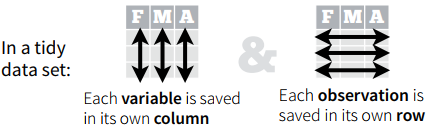

Cualquier representación de datos que no cumpla con estas dos características debe ser *limpiado*. Los verbos que se ocupan para limpiar los datos son *separate*, *extract*, *gather* y *spread*.

Tenemos el siguiente data frame, tomado de [blog tidyr](https://blog.rstudio.org/2014/07/22/introducing-tidyr/):

Qué está mal?

```r
messy <- data.frame(nombre=c("juan.perez.lopez","martha.lopez.benitez",
                             "jesus.ramirez.perez","jose.martinez.lopez",
                             "aurora.saldivar.salazar"),
                    genero_edad=c("m.35","f.23","m.30","m.25","f.33"),
                    time=c(1,3,4,5,6))

messy
```

```
##                    nombre genero_edad time
## 1        juan.perez.lopez        m.35    1
## 2    martha.lopez.benitez        f.23    3
## 3     jesus.ramirez.perez        m.30    4
## 4     jose.martinez.lopez        m.25    5
## 5 aurora.saldivar.salazar        f.33    6
```

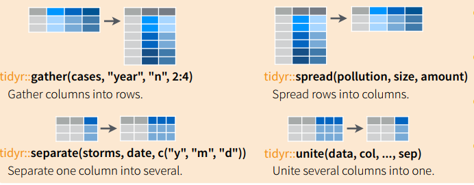

Separando los nombres

```r
semi_messy <- messy %>% separate(col=nombre, into=c("nombre",
                                      "apellido_paterno",
                                      "apellido_materno"),
                   sep="\\.")

semi_messy
```

```
##   nombre apellido_paterno apellido_materno genero_edad time
## 1   juan            perez            lopez        m.35    1
## 2 martha            lopez          benitez        f.23    3
## 3  jesus          ramirez            perez        m.30    4
## 4   jose         martinez            lopez        m.25    5
## 5 aurora         saldivar          salazar        f.33    6
```

Separando genero y edad

```r
clean <- semi_messy %>% separate(col=genero_edad, into=c("genero","edad"),
                   sep="\\.")

clean
```

```
##   nombre apellido_paterno apellido_materno genero edad time
## 1   juan            perez            lopez      m   35    1
## 2 martha            lopez          benitez      f   23    3
## 3  jesus          ramirez            perez      m   30    4
## 4   jose         martinez            lopez      m   25    5
## 5 aurora         saldivar          salazar      f   33    6
```

Otro ejemplo: ¿Qué está mal?

```r
messy <- data.frame(pais=c(rep("Afganistan",4),
                           rep("Brazil",4),
                           rep("China",4)),
                    year=c(rep(1999,2),rep(2000,2),
                           rep(1999,2),rep(2000,2),
                           rep(1999,2),rep(2000,2)),
                    llave=c("casos","poblacion","casos","poblacion",
                          "casos","poblacion","casos","poblacion",
                          "casos","poblacion","casos","poblacion"),
                    valor=c(75,1300000,134,1400000,
                            10000,100000000,12000,120000000,
                            56000,150000000,60000,170000000))

messy
```

```
##          pais year     llave    valor
## 1  Afganistan 1999     casos 7.50e+01
## 2  Afganistan 1999 poblacion 1.30e+06
## 3  Afganistan 2000     casos 1.34e+02
## 4  Afganistan 2000 poblacion 1.40e+06
## 5      Brazil 1999     casos 1.00e+04
## 6      Brazil 1999 poblacion 1.00e+08
## 7      Brazil 2000     casos 1.20e+04
## 8      Brazil 2000 poblacion 1.20e+08
## 9       China 1999     casos 5.60e+04
## 10      China 1999 poblacion 1.50e+08
## 11      China 2000     casos 6.00e+04
## 12      China 2000 poblacion 1.70e+08
```

*spread*

```r
clean <- messy %>% spread(key=llave, value=valor, fill=NA)

clean
```

```
##         pais year casos poblacion
## 1 Afganistan 1999    75   1.3e+06
## 2 Afganistan 2000   134   1.4e+06
## 3     Brazil 1999 10000   1.0e+08
## 4     Brazil 2000 12000   1.2e+08
## 5      China 1999 56000   1.5e+08
## 6      China 2000 60000   1.7e+08
```

*gather* el inverso de spread, se ocupa mucho para ggplot ;)

```r
stocks <- data_frame(
  time = as.Date('2009-01-01') + 0:9,
  X = rnorm(10, 0, 1),
  Y = rnorm(10, 0, 2),
  Z = rnorm(10, 0, 4)
)

stocks %>% gather(stock, price, -time)
```

```
## # A tibble: 30 x 3
##          time stock       price
##        <date> <chr>       <dbl>
##  1 2009-01-01     X -1.38686152
##  2 2009-01-02     X -0.19619397
##  3 2009-01-03     X -1.41558191
##  4 2009-01-04     X -2.26612225
##  5 2009-01-05     X -1.28999225
##  6 2009-01-06     X  1.15633665
##  7 2009-01-07     X  1.26829895
##  8 2009-01-08     X -0.09776003
##  9 2009-01-09     X  0.21001611
## 10 2009-01-10     X  0.41328155
## # ... with 20 more rows
```

### Tarea

A entregar el domingo **3 de septiembre 2017** 23:59:59 CST en el repositorio de la clase bajo tu carpeta alumnos/nombre_apellido con el titulo tarea_2.Rmd y tarea_2.html respectivamente. Por ejemplo:

`alumnos/liliana_millan/tarea_2.Rmd`

Con los datos que se encuentran en la carpeta de la materia en *datos/Pokemon.csv* genera un reporte en RMD que incluya un pequeño análisis exploratorio de los datos incluyendo si los datos son numéricos su media, desviación estándar, promedio, mediana, primer cuantil, tercer cuantil, valor mínimo, valor máximo, cuántas observaciones totales tiene el set

Set de datos: [Pokemon](https://www.kaggle.com/abcsds/pokemon)

- **#** id del pokemon
- **Name:** nombre del pokemon
- **Type 1:** De qué tipo es el pokemon: agua, pasto, fuego, etc.
- **Type 2:** Subtipo de pokemon
- **Total:** La suma de las variables de hit points, attack, defense, special attack, special defence, speed; indica que tan fuerte es un pokemon
- **HP:** hit points indica cuánto puede aguantar un pokemon en combate
- **Attack:** Indica cuánto ataca el pokemon en ataques normales
- **Defense:** Indica cuánto aguanta el pokemon en ataques normales
- **SP Atk:** Indica cuánto ataca el pokemon en ataques especiales
- **SP Def:** Indica cuánto aguanta el pokemon en ataques especiales
- **Speed:** Determina qué pokemon ataca primero

**Puntos a calificar:**

- Se entregó el RMD y el html generado por el RMD con el código utilizado: 1
- Cuenta con explicación de lo que se presentará en el reporte —contexto— de qué se trata el set de datos?, etc: 1.5
- Análisis exploratorio -primera aproximación-: 2
- Número de observaciones en el dataset
- Nombre de las columnas
- Promedio de aquellas variables que son numéricas
- Desviación estándar de las variables que son numéricas (qué indica eso?)
- Tipos diferentes de pokemones para el Type II
- Número de pokemones diferentes en el set de datos de acuerdo al nombre (número, no cuáles!) TIP: busca la función `unique()`
- Ocupó al menos 5 visualizaciones: 2
- Explicó lo que indica cada gráfica: 2
- ¿Cuál fue el pokemon más *fuerte*?: 1
- ¿Cúantos tipos diferentes de pokemones existen en el set de datos de acuerdo a la variable ‘Type 1’: 1

Total: 10.5

### Tutorial

- [dplyr tutorial](http://genomicsclass.github.io/book/pages/dplyr_tutorial.html)

### Referencias

- [Introducción a dplyr](https://cran.rstudio.com/web/packages/dplyr/vignettes/introduction.html)
- [Paquete dplyr](https://cran.r-project.org/web/packages/dplyr/dplyr.pdf)
- [Swirl courses](https://github.com/swirldev/swirl_courses#swirl-courses)
- [Window functons](https://cran.r-project.org/web/packages/dplyr/vignettes/window-functions.html)
- [tidyr](https://blog.rstudio.org/2014/07/22/introducing-tidyr/)
- [Data wrangling cheat sheet](https://www.rstudio.com/wp-content/uploads/2015/02/data-wrangling-cheatsheet.pdf)
- [Conexión a bases de datos dplyr](https://cran.r-project.org/web/packages/dplyr/vignettes/databases.html)